# Day13과제

### 학습목표:

- PeriodIndex 객체를 생성하는 방법을 익힌다.
  - 다양한 리샘플링 방법을 익히고 애플의 주가 데이터에 적용해본다.
- 과제:
  - https://finance.yahoo.com/ 사이트에서 몇몇 기업의 주가 데이터를 다운로드하여 concat으로 연결하여 통합된 DataFrame df로 만든다.
  - 기간: 2017년 6월 19일~2018년 6월 18일
  - 주기: Daily
  - 기업 목록: [‘AAPL’, ‘GOOG’, ‘MSFT’, ‘GS’, ‘MS’, ‘BAC’, ‘C’]
  - 데이터 칼럼: [‘Close’]
  - 위 데이터에 대하여 업샘플링, 다운샘플링, 앵커드 오프셋을 이용한 리샘플링을 연습한다.
  - 업샘플링: 4시간을 주기로 리샘플링
  - 다운샘플링: 일주일을 주기로 리샘플링, 월을 주기로 리샘플링
  - 앵커드 오프셋을 이용한 리샘플링: 매주 수요일을 주기로 리샘플링

```python
from pandas import DataFrame, Series
import pandas as pd
import numpy as np
import matplotlib.pyplot as plt
```

```python
aapl = pd.read_csv('AAPL.csv', parse_dates=True,index_col=0)
msft = pd.read_csv('MSFT.csv', parse_dates=True,index_col=0)
goog = pd.read_csv('MSFT.csv', parse_dates=True,index_col=0)
c = pd.read_csv('c.csv', parse_dates=True,index_col=0)
bac = pd.read_csv('bac.csv', parse_dates=True,index_col=0)
ms = pd.read_csv('ms.csv', parse_dates=True,index_col=0)
gs = pd.read_csv('gs.csv', parse_dates=True,index_col=0)
```

```python
ent_data=pd.concat([aapl.Close, msft.Close, goog.Close, c.Close, bac.Close, ms.Close, gs.Close],keys=['aapl','msft','goog', 'c','bac','ms','gs',])
```

```python
ent_data=ent_data.unstack(0)
```

```python
ent_data
```

| Date | aapl | msft | goog | c | bac | ms | gs |
| --- | --- | --- | --- | --- | --- | --- | --- |
| 2017-06-19 | 146.339996 | 70.870003 | 70.870003 | 64.480003 | 23.910000 | 45.720001 | 226.130005 |
| 2017-06-20 | 145.009995 | 69.910004 | 69.910004 | 63.910000 | 23.490000 | 45.500000 | 225.100006 |
| 2017-06-21 | 145.869995 | 70.269997 | 70.269997 | 63.830002 | 23.129999 | 44.910000 | 222.490005 |
| 2017-06-22 | 145.630005 | 70.260002 | 70.260002 | 63.619999 | 22.930000 | 44.610001 | 219.770004 |
| 2017-06-23 | 146.279999 | 71.209999 | 71.209999 | 63.410000 | 22.820000 | 43.689999 | 217.190002 |
| 2017-06-26 | 145.820007 | 70.529999 | 70.529999 | 63.779999 | 22.889999 | 44.000000 | 220.440002 |
| 2017-06-27 | 143.729996 | 69.209999 | 69.209999 | 64.230003 | 23.270000 | 44.220001 | 220.279999 |
| 2017-06-28 | 145.830002 | 69.800003 | 69.800003 | 65.180000 | 23.879999 | 44.320000 | 223.220001 |
| 2017-06-29 | 143.679993 | 68.489998 | 68.489998 | 66.980003 | 24.320000 | 44.750000 | 224.410004 |
| 2017-06-30 | 144.020004 | 68.930000 | 68.930000 | 66.879997 | 24.260000 | 44.560001 | 221.899994 |
| 2017-07-03 | 143.500000 | 68.169998 | 68.169998 | 68.260002 | 24.680000 | 45.610001 | 227.279999 |
| 2017-07-05 | 144.089996 | 69.080002 | 69.080002 | 68.449997 | 24.920000 | 46.160000 | 228.039993 |
| 2017-07-06 | 142.729996 | 68.570000 | 68.570000 | 67.629997 | 24.709999 | 46.130001 | 226.690002 |
| 2017-07-07 | 144.179993 | 69.459999 | 69.459999 | 67.910004 | 24.830000 | 46.049999 | 225.279999 |
| 2017-07-10 | 145.059998 | 69.980003 | 69.980003 | 67.650002 | 24.889999 | 45.990002 | 225.839996 |
| 2017-07-11 | 145.529999 | 69.989998 | 69.989998 | 66.820000 | 24.600000 | 45.480000 | 226.949997 |
| 2017-07-12 | 145.740005 | 71.150002 | 71.150002 | 66.919998 | 24.350000 | 44.959999 | 227.389999 |
| 2017-07-13 | 147.770004 | 71.769997 | 71.769997 | 67.019997 | 24.620001 | 45.520000 | 230.399994 |
| 2017-07-14 | 149.039993 | 72.779999 | 72.779999 | 66.720001 | 24.209999 | 45.200001 | 228.600006 |
| 2017-07-17 | 149.559998 | 73.349998 | 73.349998 | 66.830002 | 24.020000 | 45.330002 | 229.259995 |
| 2017-07-18 | 150.080002 | 73.300003 | 73.300003 | 66.889999 | 23.900000 | 45.139999 | 223.309998 |
| 2017-07-19 | 151.020004 | 73.860001 | 73.860001 | 66.699997 | 24.059999 | 46.619999 | 222.869995 |
| 2017-07-20 | 150.339996 | 74.220001 | 74.220001 | 66.360001 | 23.940001 | 46.509998 | 222.300003 |
| 2017-07-21 | 150.270004 | 73.790001 | 73.790001 | 66.000000 | 23.799999 | 46.590000 | 220.179993 |
| 2017-07-24 | 152.089996 | 73.599998 | 73.599998 | 66.099998 | 23.910000 | 46.709999 | 218.179993 |
| 2017-07-25 | 152.740005 | 74.190002 | 74.190002 | 68.029999 | 24.480000 | 47.610001 | 221.580002 |
| 2017-07-26 | 153.460007 | 74.050003 | 74.050003 | 67.980003 | 24.209999 | 47.209999 | 222.250000 |
| 2017-07-27 | 150.559998 | 73.160004 | 73.160004 | 67.599998 | 24.110001 | 47.090000 | 221.479996 |
| 2017-07-28 | 149.500000 | 73.040001 | 73.040001 | 67.430000 | 24.030001 | 46.660000 | 223.610001 |
| 2017-07-31 | 148.729996 | 72.699997 | 72.699997 | 68.449997 | 24.120001 | 46.900002 | 225.330002 |
| ... | ... | ... | ... | ... | ... | ... | ... |
| 2018-05-07 | 185.160004 | 96.220001 | 96.220001 | 68.500000 | 29.639999 | 52.389999 | 237.199997 |
| 2018-05-08 | 186.050003 | 95.809998 | 95.809998 | 71.000000 | 29.930000 | 53.380001 | 237.000000 |
| 2018-05-09 | 187.360001 | 96.940002 | 96.940002 | 71.949997 | 30.719999 | 54.139999 | 241.729996 |
| 2018-05-10 | 190.039993 | 97.910004 | 97.910004 | 72.570000 | 30.889999 | 55.040001 | 243.440002 |
| 2018-05-11 | 188.589996 | 97.699997 | 97.699997 | 72.860001 | 30.920000 | 55.200001 | 242.919998 |
| 2018-05-14 | 188.149994 | 98.029999 | 98.029999 | 72.620003 | 31.120001 | 55.220001 | 243.910004 |
| 2018-05-15 | 186.440002 | 97.320000 | 97.320000 | 72.680000 | 31.219999 | 54.849998 | 241.559998 |
| 2018-05-16 | 188.179993 | 97.150002 | 97.150002 | 71.949997 | 31.059999 | 54.970001 | 240.960007 |
| 2018-05-17 | 186.990005 | 96.180000 | 96.180000 | 71.559998 | 30.809999 | 54.869999 | 239.100006 |
| 2018-05-18 | 186.309998 | 96.360001 | 96.360001 | 69.959999 | 30.260000 | 53.919998 | 237.000000 |
| 2018-05-21 | 187.630005 | 97.599998 | 97.599998 | 70.430000 | 30.549999 | 54.360001 | 237.699997 |
| 2018-05-22 | 187.160004 | 97.500000 | 97.500000 | 71.080002 | 30.889999 | 54.880001 | 238.000000 |
| 2018-05-23 | 188.360001 | 98.660004 | 98.660004 | 70.239998 | 30.440001 | 54.349998 | 237.809998 |
| 2018-05-24 | 188.149994 | 98.309998 | 98.309998 | 69.309998 | 30.209999 | 54.000000 | 236.100006 |
| 2018-05-25 | 188.580002 | 98.360001 | 98.360001 | 68.440002 | 30.160000 | 53.009998 | 235.009995 |
| 2018-05-29 | 187.899994 | 98.010002 | 98.010002 | 65.709999 | 28.959999 | 49.959999 | 227.029999 |
| 2018-05-30 | 187.500000 | 98.949997 | 98.949997 | 66.680000 | 29.490000 | 50.970001 | 229.160004 |
| 2018-05-31 | 186.869995 | 98.839996 | 98.839996 | 66.690002 | 29.040001 | 50.139999 | 225.880005 |
| 2018-06-01 | 190.240005 | 100.790001 | 100.790001 | 67.279999 | 29.400000 | 51.209999 | 228.350006 |
| 2018-06-04 | 191.830002 | 101.669998 | 101.669998 | 67.339996 | 29.400000 | 51.549999 | 229.889999 |
| 2018-06-05 | 193.309998 | 102.190002 | 102.190002 | 66.760002 | 29.120001 | 50.779999 | 228.339996 |
| 2018-06-06 | 193.979996 | 102.489998 | 102.489998 | 68.230003 | 30.040001 | 51.910000 | 232.229996 |
| 2018-06-07 | 193.460007 | 100.879997 | 100.879997 | 68.449997 | 30.090000 | 52.139999 | 233.449997 |
| 2018-06-08 | 191.699997 | 101.629997 | 101.629997 | 68.470001 | 30.010000 | 51.910000 | 233.389999 |
| 2018-06-11 | 191.229996 | 101.050003 | 101.050003 | 68.110001 | 30.059999 | 51.779999 | 234.089996 |
| 2018-06-12 | 192.279999 | 101.309998 | 101.309998 | 67.610001 | 29.900000 | 51.320000 | 232.630005 |
| 2018-06-13 | 190.699997 | 100.849998 | 100.849998 | 67.290001 | 29.840000 | 51.599998 | 233.830002 |
| 2018-06-14 | 190.800003 | 101.419998 | 101.419998 | 66.160004 | 29.500000 | 51.310001 | 233.649994 |
| 2018-06-15 | 188.839996 | 100.129997 | 100.129997 | 66.339996 | 29.280001 | 51.160000 | 231.919998 |
| 2018-06-18 | 188.740005 | 100.860001 | 100.860001 | 66.750000 | 29.400000 | 50.770000 | 231.389999 |

252 rows × 7 columns

업샘플링 : 4시간을 주기로 리샘플링

```python
ent_data_4h = ent_data.resample('4H').ffill()
ent_data_4h
```

| Date | aapl | msft | goog | c | bac | ms | gs |
| --- | --- | --- | --- | --- | --- | --- | --- |
| 2017-06-19 00:00:00 | 146.339996 | 70.870003 | 70.870003 | 64.480003 | 23.910000 | 45.720001 | 226.130005 |
| 2017-06-19 04:00:00 | 146.339996 | 70.870003 | 70.870003 | 64.480003 | 23.910000 | 45.720001 | 226.130005 |
| 2017-06-19 08:00:00 | 146.339996 | 70.870003 | 70.870003 | 64.480003 | 23.910000 | 45.720001 | 226.130005 |
| 2017-06-19 12:00:00 | 146.339996 | 70.870003 | 70.870003 | 64.480003 | 23.910000 | 45.720001 | 226.130005 |
| 2017-06-19 16:00:00 | 146.339996 | 70.870003 | 70.870003 | 64.480003 | 23.910000 | 45.720001 | 226.130005 |
| 2017-06-19 20:00:00 | 146.339996 | 70.870003 | 70.870003 | 64.480003 | 23.910000 | 45.720001 | 226.130005 |
| 2017-06-20 00:00:00 | 145.009995 | 69.910004 | 69.910004 | 63.910000 | 23.490000 | 45.500000 | 225.100006 |
| 2017-06-20 04:00:00 | 145.009995 | 69.910004 | 69.910004 | 63.910000 | 23.490000 | 45.500000 | 225.100006 |
| 2017-06-20 08:00:00 | 145.009995 | 69.910004 | 69.910004 | 63.910000 | 23.490000 | 45.500000 | 225.100006 |
| 2017-06-20 12:00:00 | 145.009995 | 69.910004 | 69.910004 | 63.910000 | 23.490000 | 45.500000 | 225.100006 |
| 2017-06-20 16:00:00 | 145.009995 | 69.910004 | 69.910004 | 63.910000 | 23.490000 | 45.500000 | 225.100006 |
| 2017-06-20 20:00:00 | 145.009995 | 69.910004 | 69.910004 | 63.910000 | 23.490000 | 45.500000 | 225.100006 |
| 2017-06-21 00:00:00 | 145.869995 | 70.269997 | 70.269997 | 63.830002 | 23.129999 | 44.910000 | 222.490005 |
| 2017-06-21 04:00:00 | 145.869995 | 70.269997 | 70.269997 | 63.830002 | 23.129999 | 44.910000 | 222.490005 |
| 2017-06-21 08:00:00 | 145.869995 | 70.269997 | 70.269997 | 63.830002 | 23.129999 | 44.910000 | 222.490005 |
| 2017-06-21 12:00:00 | 145.869995 | 70.269997 | 70.269997 | 63.830002 | 23.129999 | 44.910000 | 222.490005 |
| 2017-06-21 16:00:00 | 145.869995 | 70.269997 | 70.269997 | 63.830002 | 23.129999 | 44.910000 | 222.490005 |
| 2017-06-21 20:00:00 | 145.869995 | 70.269997 | 70.269997 | 63.830002 | 23.129999 | 44.910000 | 222.490005 |
| 2017-06-22 00:00:00 | 145.630005 | 70.260002 | 70.260002 | 63.619999 | 22.930000 | 44.610001 | 219.770004 |
| 2017-06-22 04:00:00 | 145.630005 | 70.260002 | 70.260002 | 63.619999 | 22.930000 | 44.610001 | 219.770004 |
| 2017-06-22 08:00:00 | 145.630005 | 70.260002 | 70.260002 | 63.619999 | 22.930000 | 44.610001 | 219.770004 |
| 2017-06-22 12:00:00 | 145.630005 | 70.260002 | 70.260002 | 63.619999 | 22.930000 | 44.610001 | 219.770004 |
| 2017-06-22 16:00:00 | 145.630005 | 70.260002 | 70.260002 | 63.619999 | 22.930000 | 44.610001 | 219.770004 |
| 2017-06-22 20:00:00 | 145.630005 | 70.260002 | 70.260002 | 63.619999 | 22.930000 | 44.610001 | 219.770004 |
| 2017-06-23 00:00:00 | 146.279999 | 71.209999 | 71.209999 | 63.410000 | 22.820000 | 43.689999 | 217.190002 |
| 2017-06-23 04:00:00 | 146.279999 | 71.209999 | 71.209999 | 63.410000 | 22.820000 | 43.689999 | 217.190002 |
| 2017-06-23 08:00:00 | 146.279999 | 71.209999 | 71.209999 | 63.410000 | 22.820000 | 43.689999 | 217.190002 |
| 2017-06-23 12:00:00 | 146.279999 | 71.209999 | 71.209999 | 63.410000 | 22.820000 | 43.689999 | 217.190002 |
| 2017-06-23 16:00:00 | 146.279999 | 71.209999 | 71.209999 | 63.410000 | 22.820000 | 43.689999 | 217.190002 |
| 2017-06-23 20:00:00 | 146.279999 | 71.209999 | 71.209999 | 63.410000 | 22.820000 | 43.689999 | 217.190002 |
| ... | ... | ... | ... | ... | ... | ... | ... |
| 2018-06-13 04:00:00 | 190.699997 | 100.849998 | 100.849998 | 67.290001 | 29.840000 | 51.599998 | 233.830002 |
| 2018-06-13 08:00:00 | 190.699997 | 100.849998 | 100.849998 | 67.290001 | 29.840000 | 51.599998 | 233.830002 |
| 2018-06-13 12:00:00 | 190.699997 | 100.849998 | 100.849998 | 67.290001 | 29.840000 | 51.599998 | 233.830002 |
| 2018-06-13 16:00:00 | 190.699997 | 100.849998 | 100.849998 | 67.290001 | 29.840000 | 51.599998 | 233.830002 |
| 2018-06-13 20:00:00 | 190.699997 | 100.849998 | 100.849998 | 67.290001 | 29.840000 | 51.599998 | 233.830002 |
| 2018-06-14 00:00:00 | 190.800003 | 101.419998 | 101.419998 | 66.160004 | 29.500000 | 51.310001 | 233.649994 |
| 2018-06-14 04:00:00 | 190.800003 | 101.419998 | 101.419998 | 66.160004 | 29.500000 | 51.310001 | 233.649994 |
| 2018-06-14 08:00:00 | 190.800003 | 101.419998 | 101.419998 | 66.160004 | 29.500000 | 51.310001 | 233.649994 |
| 2018-06-14 12:00:00 | 190.800003 | 101.419998 | 101.419998 | 66.160004 | 29.500000 | 51.310001 | 233.649994 |
| 2018-06-14 16:00:00 | 190.800003 | 101.419998 | 101.419998 | 66.160004 | 29.500000 | 51.310001 | 233.649994 |
| 2018-06-14 20:00:00 | 190.800003 | 101.419998 | 101.419998 | 66.160004 | 29.500000 | 51.310001 | 233.649994 |
| 2018-06-15 00:00:00 | 188.839996 | 100.129997 | 100.129997 | 66.339996 | 29.280001 | 51.160000 | 231.919998 |
| 2018-06-15 04:00:00 | 188.839996 | 100.129997 | 100.129997 | 66.339996 | 29.280001 | 51.160000 | 231.919998 |
| 2018-06-15 08:00:00 | 188.839996 | 100.129997 | 100.129997 | 66.339996 | 29.280001 | 51.160000 | 231.919998 |
| 2018-06-15 12:00:00 | 188.839996 | 100.129997 | 100.129997 | 66.339996 | 29.280001 | 51.160000 | 231.919998 |
| 2018-06-15 16:00:00 | 188.839996 | 100.129997 | 100.129997 | 66.339996 | 29.280001 | 51.160000 | 231.919998 |
| 2018-06-15 20:00:00 | 188.839996 | 100.129997 | 100.129997 | 66.339996 | 29.280001 | 51.160000 | 231.919998 |
| 2018-06-16 00:00:00 | 188.839996 | 100.129997 | 100.129997 | 66.339996 | 29.280001 | 51.160000 | 231.919998 |
| 2018-06-16 04:00:00 | 188.839996 | 100.129997 | 100.129997 | 66.339996 | 29.280001 | 51.160000 | 231.919998 |
| 2018-06-16 08:00:00 | 188.839996 | 100.129997 | 100.129997 | 66.339996 | 29.280001 | 51.160000 | 231.919998 |
| 2018-06-16 12:00:00 | 188.839996 | 100.129997 | 100.129997 | 66.339996 | 29.280001 | 51.160000 | 231.919998 |
| 2018-06-16 16:00:00 | 188.839996 | 100.129997 | 100.129997 | 66.339996 | 29.280001 | 51.160000 | 231.919998 |
| 2018-06-16 20:00:00 | 188.839996 | 100.129997 | 100.129997 | 66.339996 | 29.280001 | 51.160000 | 231.919998 |
| 2018-06-17 00:00:00 | 188.839996 | 100.129997 | 100.129997 | 66.339996 | 29.280001 | 51.160000 | 231.919998 |
| 2018-06-17 04:00:00 | 188.839996 | 100.129997 | 100.129997 | 66.339996 | 29.280001 | 51.160000 | 231.919998 |
| 2018-06-17 08:00:00 | 188.839996 | 100.129997 | 100.129997 | 66.339996 | 29.280001 | 51.160000 | 231.919998 |
| 2018-06-17 12:00:00 | 188.839996 | 100.129997 | 100.129997 | 66.339996 | 29.280001 | 51.160000 | 231.919998 |
| 2018-06-17 16:00:00 | 188.839996 | 100.129997 | 100.129997 | 66.339996 | 29.280001 | 51.160000 | 231.919998 |
| 2018-06-17 20:00:00 | 188.839996 | 100.129997 | 100.129997 | 66.339996 | 29.280001 | 51.160000 | 231.919998 |
| 2018-06-18 00:00:00 | 188.740005 | 100.860001 | 100.860001 | 66.750000 | 29.400000 | 50.770000 | 231.389999 |

2185 rows × 7 columns

다운샘플링 : 일주일을 주기로 리샘플링, 월을 주기로 리샘플링

```python
ent_data_week = ent_data.resample('W').mean()
ent_data_week
```

| Date | aapl | msft | goog | c | bac | ms | gs |
| --- | --- | --- | --- | --- | --- | --- | --- |
| 2017-06-25 | 145.825998 | 70.504001 | 70.504001 | 63.850001 | 23.256000 | 44.886000 | 222.136004 |
| 2017-07-02 | 144.616000 | 69.392000 | 69.392000 | 65.410000 | 23.724000 | 44.370000 | 222.050000 |
| 2017-07-09 | 143.624996 | 68.820000 | 68.820000 | 68.062500 | 24.785000 | 45.987500 | 226.822498 |
| 2017-07-16 | 146.628000 | 71.134000 | 71.134000 | 67.026000 | 24.534000 | 45.430000 | 227.835998 |
| 2017-07-23 | 150.254001 | 73.704001 | 73.704001 | 66.556000 | 23.944000 | 46.038000 | 223.583997 |
| 2017-07-30 | 151.670001 | 73.608002 | 73.608002 | 67.428000 | 24.148000 | 47.056000 | 221.419998 |
| 2017-08-06 | 153.576001 | 72.474001 | 72.474001 | 68.915999 | 24.500000 | 47.356001 | 226.476001 |
| 2017-08-13 | 158.550000 | 72.314002 | 72.314002 | 68.074000 | 24.516000 | 47.168001 | 229.125998 |
| 2017-08-20 | 159.552002 | 73.070000 | 73.070000 | 67.350000 | 24.068000 | 45.885999 | 224.825998 |
| 2017-08-27 | 159.220001 | 72.708002 | 72.708002 | 67.114000 | 23.716000 | 45.598000 | 222.514001 |
| 2017-09-03 | 163.156003 | 73.720001 | 73.720001 | 67.982001 | 23.830000 | 45.635999 | 222.470004 |
| 2017-09-10 | 160.970001 | 73.832500 | 73.832500 | 66.677500 | 23.144999 | 44.509999 | 217.415001 |
| 2017-09-17 | 160.034000 | 74.945999 | 74.945999 | 68.834000 | 24.052000 | 46.029999 | 225.128000 |
| 2017-09-24 | 155.750000 | 74.832002 | 74.832002 | 71.274001 | 24.960000 | 47.871999 | 229.709998 |
| 2017-10-01 | 153.063998 | 73.746001 | 73.746001 | 71.889999 | 25.154000 | 47.918000 | 233.523999 |
| 2017-10-08 | 154.491998 | 75.106001 | 75.106001 | 74.670000 | 25.906000 | 49.319999 | 242.931998 |
| 2017-10-15 | 156.256000 | 76.722000 | 76.722000 | 73.998001 | 25.778000 | 48.988000 | 241.226001 |
| 2017-10-22 | 158.467999 | 77.914000 | 77.914000 | 72.698000 | 26.534000 | 49.736000 | 241.050000 |
| 2017-10-29 | 158.028003 | 79.778000 | 79.778000 | 73.810001 | 27.602000 | 50.828000 | 242.422003 |
| 2017-11-05 | 168.651999 | 83.688000 | 83.688000 | 74.020000 | 27.642000 | 50.106000 | 243.781998 |
| 2017-11-12 | 175.170001 | 84.251999 | 84.251999 | 72.706000 | 26.944000 | 49.229999 | 241.097998 |
| 2017-11-19 | 171.128000 | 83.312001 | 83.312001 | 71.650000 | 26.562000 | 48.482000 | 238.502002 |
| 2017-11-26 | 173.262501 | 83.155001 | 83.155001 | 72.177500 | 26.680000 | 49.160001 | 237.132500 |
| 2017-12-03 | 171.908002 | 84.103999 | 84.103999 | 74.228000 | 27.756000 | 50.856001 | 242.494000 |
| 2017-12-10 | 169.428000 | 82.420000 | 82.420000 | 75.954001 | 28.892000 | 52.323999 | 248.767999 |
| 2017-12-17 | 172.566000 | 85.540001 | 85.540001 | 75.165999 | 28.974000 | 53.107999 | 255.204001 |
| 2017-12-24 | 175.065997 | 85.748000 | 85.748000 | 75.267999 | 29.622000 | 52.856000 | 258.332001 |
| 2017-12-31 | 170.370003 | 85.592501 | 85.592501 | 74.790001 | 29.707500 | 52.540001 | 256.232498 |
| 2018-01-07 | 173.129998 | 86.899999 | 86.899999 | 74.967501 | 30.055000 | 52.690001 | 255.327495 |
| 2018-01-14 | 175.067999 | 88.400000 | 88.400000 | 75.577999 | 30.558000 | 53.888000 | 254.448001 |
| 2018-01-21 | 178.252503 | 89.647499 | 89.647499 | 77.567501 | 31.405000 | 55.812499 | 254.799995 |
| 2018-01-28 | 174.175998 | 92.344001 | 92.344001 | 79.222000 | 32.048000 | 57.184000 | 264.891998 |
| 2018-02-04 | 166.128000 | 93.542000 | 93.542000 | 78.656000 | 32.122000 | 56.706000 | 268.316010 |
| 2018-02-11 | 158.123999 | 88.426001 | 88.426001 | 73.726000 | 30.556000 | 53.072000 | 252.112006 |
| 2018-02-18 | 167.967999 | 90.886000 | 90.886000 | 76.110001 | 31.696000 | 54.482000 | 261.313996 |
| 2018-02-25 | 172.730003 | 92.500000 | 92.500000 | 76.702499 | 31.880000 | 55.272500 | 264.122498 |
| 2018-03-04 | 177.338000 | 93.857999 | 93.857999 | 75.372000 | 31.991999 | 55.796001 | 263.403998 |
| 2018-03-11 | 177.088000 | 94.358000 | 94.358000 | 74.523999 | 32.268001 | 56.912000 | 266.501996 |
| 2018-03-18 | 179.360000 | 94.761999 | 94.761999 | 74.242000 | 32.321999 | 57.732000 | 268.109998 |
| 2018-03-25 | 171.120004 | 91.094000 | 91.094000 | 71.429999 | 31.110000 | 55.648000 | 257.086002 |
| 2018-04-01 | 168.842499 | 90.977499 | 90.977499 | 68.455000 | 29.835000 | 53.580000 | 250.842499 |
| 2018-04-08 | 169.572000 | 90.634000 | 90.634000 | 68.864000 | 29.745999 | 53.492000 | 251.266000 |
| 2018-04-15 | 172.922000 | 92.434000 | 92.434000 | 70.596000 | 30.140000 | 53.411999 | 255.442001 |
| 2018-04-22 | 174.084002 | 95.558000 | 95.558000 | 69.814000 | 29.988000 | 53.812000 | 254.328003 |
| 2018-04-29 | 163.674002 | 94.172000 | 94.172000 | 69.226001 | 30.174000 | 52.562000 | 241.656000 |
| 2018-05-06 | 174.330002 | 94.252001 | 94.252001 | 68.078000 | 29.590000 | 51.522001 | 235.480002 |
| 2018-05-13 | 187.439999 | 96.916000 | 96.916000 | 71.376000 | 30.419999 | 54.030000 | 240.457999 |
| 2018-05-20 | 187.213998 | 97.008000 | 97.008000 | 71.753999 | 30.894000 | 54.765999 | 240.506003 |
| 2018-05-27 | 187.976001 | 98.086000 | 98.086000 | 69.900000 | 30.450000 | 54.120000 | 236.923999 |
| 2018-06-03 | 188.127499 | 99.147499 | 99.147499 | 66.590000 | 29.222500 | 50.569999 | 227.605004 |
| 2018-06-10 | 192.856000 | 101.771998 | 101.771998 | 67.850000 | 29.732000 | 51.657999 | 231.459997 |
| 2018-06-17 | 190.769998 | 100.951999 | 100.951999 | 67.102001 | 29.716000 | 51.434000 | 233.223999 |
| 2018-06-24 | 188.740005 | 100.860001 | 100.860001 | 66.750000 | 29.400000 | 50.770000 | 231.389999 |

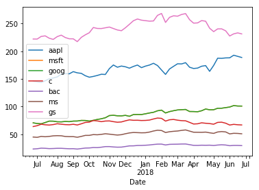

```python
ent_data_week.plot()
```

```python
ent_data_month = ent_data.resample('M').mean()
ent_data_month
```

| Date | aapl | msft | goog | c | bac | ms | gs |
| --- | --- | --- | --- | --- | --- | --- | --- |
| 2017-06-30 | 145.220999 | 69.948000 | 69.948000 | 64.630001 | 23.490000 | 44.628000 | 222.093002 |
| 2017-07-31 | 148.299500 | 72.010500 | 72.010500 | 67.287500 | 24.319500 | 46.173500 | 224.840998 |
| 2017-08-31 | 159.021306 | 72.816958 | 72.816958 | 67.832609 | 24.127826 | 46.310000 | 225.036957 |
| 2017-09-30 | 157.608500 | 74.344501 | 74.344501 | 69.764000 | 24.375000 | 46.666500 | 226.867500 |
| 2017-10-31 | 157.817273 | 77.939546 | 77.939546 | 73.780000 | 26.549545 | 49.764545 | 241.887273 |
| 2017-11-30 | 172.406191 | 83.717619 | 83.717619 | 72.806666 | 27.054762 | 49.409524 | 240.266190 |
| 2017-12-31 | 171.891500 | 84.758500 | 84.758500 | 75.330500 | 29.218500 | 52.677500 | 254.270000 |
| 2018-01-31 | 174.005237 | 90.075238 | 90.075238 | 77.200000 | 31.191905 | 55.236666 | 259.358095 |
| 2018-02-28 | 167.638947 | 91.367895 | 91.367895 | 75.880526 | 31.583158 | 54.817895 | 260.947895 |
| 2018-03-31 | 174.496192 | 92.899047 | 92.899047 | 72.482857 | 31.473809 | 55.952857 | 260.798094 |
| 2018-04-30 | 169.834287 | 93.214762 | 93.214762 | 69.560476 | 30.007619 | 53.238571 | 250.085239 |
| 2018-05-31 | 185.536818 | 96.981364 | 96.981364 | 69.834091 | 30.197272 | 53.256364 | 236.844546 |
| 2018-06-30 | 191.425833 | 101.272499 | 101.272499 | 67.399167 | 29.670000 | 51.453333 | 231.929999 |

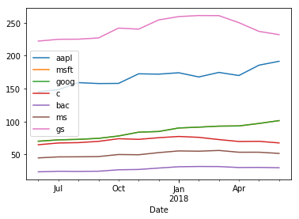

```python
ent_data_month.plot()
```

앵커드 오프셋을 이용한 리샘플링: 매주 수요일을 주기로 리샘플링

```python
ent_data_WED = ent_data.resample('W-WED').mean()
ent_data_WED
```

| Date | aapl | msft | goog | c | bac | ms | gs |
| --- | --- | --- | --- | --- | --- | --- | --- |
| 2017-06-21 | 145.739995 | 70.350001 | 70.350001 | 64.073335 | 23.510000 | 45.376667 | 224.573339 |
| 2017-06-28 | 145.458002 | 70.202000 | 70.202000 | 64.044000 | 23.158000 | 44.168000 | 220.180002 |
| 2017-07-05 | 143.822498 | 68.667500 | 68.667500 | 67.642500 | 24.545000 | 45.270001 | 225.407498 |
| 2017-07-12 | 144.647998 | 69.830000 | 69.830000 | 67.386000 | 24.676000 | 45.722000 | 226.429999 |
| 2017-07-19 | 149.494000 | 73.012000 | 73.012000 | 66.831999 | 24.162000 | 45.562000 | 226.887998 |
| 2017-07-26 | 151.780002 | 73.970001 | 73.970001 | 66.894000 | 24.068000 | 46.925999 | 220.897998 |
| 2017-08-02 | 151.195999 | 72.748001 | 72.748001 | 68.499998 | 24.260001 | 47.038001 | 224.738001 |
| 2017-08-09 | 158.382001 | 72.498001 | 72.498001 | 68.692000 | 24.788000 | 47.846001 | 229.951999 |
| 2017-08-16 | 159.040002 | 72.874001 | 72.874001 | 67.518001 | 24.212000 | 46.179999 | 226.041998 |
| 2017-08-23 | 158.466001 | 72.584001 | 72.584001 | 66.642000 | 23.646000 | 45.306000 | 222.135998 |
| 2017-08-30 | 161.372003 | 73.080002 | 73.080002 | 67.768001 | 23.756000 | 45.685999 | 221.638003 |
| 2017-09-06 | 163.010002 | 73.930001 | 73.930001 | 67.772501 | 23.674999 | 45.412499 | 221.557503 |
| 2017-09-13 | 160.379999 | 74.594000 | 74.594000 | 67.623999 | 23.500000 | 45.042000 | 221.323999 |
| 2017-09-20 | 158.326001 | 75.124001 | 75.124001 | 70.298000 | 24.648000 | 47.179999 | 227.660001 |
| 2017-09-27 | 152.639999 | 73.798001 | 73.798001 | 71.444000 | 25.032000 | 47.950000 | 231.455997 |
| 2017-10-04 | 153.833997 | 74.384001 | 74.384001 | 73.476000 | 25.596000 | 48.705999 | 239.047998 |
| 2017-10-11 | 155.795999 | 76.194000 | 76.194000 | 75.374000 | 25.990000 | 49.488000 | 243.976001 |
| 2017-10-18 | 158.620001 | 77.492000 | 77.492000 | 72.312001 | 26.040000 | 49.020000 | 239.772000 |
| 2017-10-25 | 156.382001 | 78.608000 | 78.608000 | 73.559999 | 27.244000 | 50.536000 | 242.680002 |
| 2017-11-01 | 164.622000 | 82.564000 | 82.564000 | 73.794000 | 27.612000 | 50.404000 | 242.212000 |
| 2017-11-08 | 173.182001 | 84.298000 | 84.298000 | 73.528000 | 27.482000 | 49.801999 | 243.166000 |
| 2017-11-15 | 172.988000 | 83.784001 | 83.784001 | 71.986000 | 26.486000 | 48.538000 | 239.211999 |
| 2017-11-22 | 171.866000 | 82.992000 | 82.992000 | 71.938000 | 26.702000 | 48.976000 | 237.994000 |
| 2017-11-29 | 172.902500 | 83.837499 | 83.837499 | 73.037498 | 27.275000 | 49.945001 | 237.957501 |
| 2017-12-06 | 170.270001 | 82.775999 | 82.775999 | 76.018001 | 28.580000 | 51.988000 | 248.303998 |
| 2017-12-13 | 171.066000 | 84.562001 | 84.562001 | 75.566000 | 28.986000 | 53.007999 | 252.456000 |
| 2017-12-20 | 174.300000 | 85.853999 | 85.853999 | 74.743999 | 29.236000 | 52.883999 | 256.866000 |
| 2017-12-27 | 172.797501 | 85.530001 | 85.530001 | 75.244999 | 29.802500 | 52.660001 | 258.412502 |
| 2018-01-03 | 171.199997 | 85.889999 | 85.889999 | 74.610001 | 29.755000 | 52.410001 | 255.054996 |
| 2018-01-10 | 174.200000 | 87.924001 | 87.924001 | 75.282001 | 30.292000 | 53.272000 | 254.485999 |
| 2018-01-17 | 176.915001 | 89.042499 | 89.042499 | 76.744999 | 31.067500 | 54.817499 | 256.067497 |
| 2018-01-24 | 177.195999 | 91.086000 | 91.086000 | 78.456000 | 31.830000 | 56.962000 | 258.875995 |
| 2018-01-31 | 168.995999 | 93.612000 | 93.612000 | 79.316002 | 32.090000 | 57.001999 | 269.296008 |
| 2018-02-07 | 161.467999 | 90.996001 | 90.996001 | 75.859998 | 31.432000 | 54.872000 | 259.436008 |
| 2018-02-14 | 161.195999 | 88.592000 | 88.592000 | 74.440001 | 30.874000 | 53.160000 | 253.384000 |
| 2018-02-21 | 172.085003 | 92.217501 | 92.217501 | 76.840000 | 31.995000 | 55.175000 | 265.897499 |
| 2018-02-28 | 176.695999 | 93.835999 | 93.835999 | 76.573999 | 32.114000 | 56.136000 | 266.063996 |
| 2018-03-07 | 175.946002 | 93.344000 | 93.344000 | 73.948000 | 31.906000 | 55.632002 | 262.059998 |
| 2018-03-14 | 179.410000 | 95.200000 | 95.200000 | 74.924001 | 32.452000 | 57.912000 | 268.689996 |
| 2018-03-21 | 175.696002 | 93.455999 | 93.455999 | 73.149998 | 32.019999 | 57.252000 | 264.356000 |
| 2018-03-28 | 168.276001 | 89.922000 | 89.922000 | 68.906000 | 29.814000 | 53.414000 | 249.873999 |
| 2018-04-04 | 168.614998 | 90.457499 | 90.457499 | 68.250000 | 29.692500 | 53.379999 | 250.602501 |
| 2018-04-11 | 171.384003 | 91.623999 | 91.623999 | 69.732000 | 30.040000 | 53.626000 | 253.496002 |
| 2018-04-18 | 176.154001 | 94.668001 | 94.668001 | 70.386000 | 29.990000 | 53.346000 | 256.204001 |
| 2018-04-25 | 166.070001 | 94.378000 | 94.378000 | 69.648001 | 30.218000 | 53.582000 | 246.904001 |
| 2018-05-02 | 167.494003 | 94.422000 | 94.422000 | 68.535999 | 29.934000 | 51.838001 | 237.788000 |
| 2018-05-09 | 183.858002 | 95.640001 | 95.640001 | 69.466000 | 29.758000 | 52.478001 | 236.856000 |
| 2018-05-16 | 188.279996 | 97.622000 | 97.622000 | 72.536000 | 31.042000 | 55.056000 | 242.558002 |
| 2018-05-23 | 187.290003 | 97.260001 | 97.260001 | 70.653999 | 30.590000 | 54.475999 | 237.922000 |
| 2018-05-30 | 188.032498 | 98.407500 | 98.407500 | 67.535000 | 29.704999 | 51.984999 | 231.825001 |
| 2018-06-06 | 191.245999 | 101.195999 | 101.195999 | 67.260000 | 29.400001 | 51.117999 | 228.938000 |
| 2018-06-13 | 191.873999 | 101.143999 | 101.143999 | 67.986000 | 29.980000 | 51.749999 | 233.478000 |
| 2018-06-20 | 189.460001 | 100.803332 | 100.803332 | 66.416667 | 29.393334 | 51.080000 | 232.319997 |

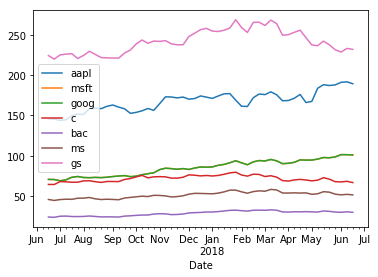

```python
ent_data_WED.plot()
```

3째주 금요일

```python
ent_data_WOM3FRI = ent_data.resample('WOM-3FRI').mean()
```

```python
ent_data_WOM3FRI
```

| Date | aapl | msft | goog | c | bac | ms | gs |
| --- | --- | --- | --- | --- | --- | --- | --- |
| 2017-06-16 | 146.123912 | 70.659131 | 70.659131 | 66.106957 | 24.027391 | 45.260000 | 224.571304 |
| 2017-07-21 | 155.475501 | 72.931501 | 72.931501 | 67.912999 | 24.317000 | 46.926500 | 225.363499 |
| 2017-08-18 | 160.713159 | 73.651580 | 73.651580 | 67.573684 | 23.674210 | 45.428947 | 221.955264 |
| 2017-09-15 | 155.751199 | 75.524001 | 75.524001 | 72.726400 | 25.554800 | 48.603600 | 236.907999 |
| 2017-10-20 | 167.549501 | 82.578000 | 82.578000 | 73.156500 | 27.215000 | 49.760500 | 241.786500 |
| 2017-11-17 | 171.512632 | 83.604737 | 83.604737 | 74.316316 | 28.021579 | 51.246316 | 245.353158 |
| 2017-12-15 | 174.235909 | 87.097727 | 87.097727 | 75.454545 | 30.131364 | 53.342273 | 255.926817 |
| 2018-01-19 | 166.900500 | 91.199500 | 91.199500 | 77.002500 | 31.593000 | 55.477000 | 261.083502 |
| 2018-02-16 | 176.540000 | 93.804736 | 93.804736 | 75.307894 | 32.117368 | 56.364211 | 265.609997 |
| 2018-03-16 | 171.923335 | 92.171250 | 92.171250 | 70.033750 | 30.257083 | 54.132917 | 254.567501 |
| 2018-04-20 | 177.135000 | 95.519000 | 95.519000 | 70.110500 | 30.269500 | 53.247000 | 240.273001 |
| 2018-05-18 | 189.894210 | 99.835262 | 99.835262 | 68.117895 | 29.861053 | 52.163157 | 232.817894 |
| 2018-06-15 | 188.790000 | 100.494999 | 100.494999 | 66.544998 | 29.340001 | 50.965000 | 231.654999 |

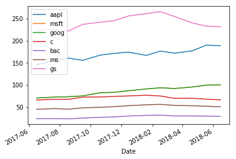

```python
ent_data_WOM3FRI.plot()
```